# edgefinder

Haim Bar

2020-07-29

The edgefinder package is used to find edges in gene networks using co-expression data. The input to the program is a normalized expression matrix, with genes (nodes) in the rows, and samples in the columns. The program calculates the pair-wise correlations, performs Fisher’s Z transformation, and fits the L2N model to the transformed data. L2N is a mixture model with three components: the uncorrelated pairs belong to the null component which is assumed to be normally distributed, and the correlated pairs belong to one of the two non-null components which are assumed to follow lognormal distributions.

Typical datasets consist of hundreds, or thousands of genes, and hence a very large number of pairs. Therefore, edgefinder randomly selects a subset of the pairs (the default number of pairs is 20,000), fits the L2N model to the subset, and calculates the component probabilities for *all* possible pairs. Using the posterior probabilities, edgefinder determines which pairs are highly correlated while controlling the false discovery rate. Note that edgefinder makes no assumptions about the structure of the network.

The edgefinder package depends on the ‘Matrix’ package, to allow for efficient storage and computation of large co-occurrence matrices. For simulating datasets we used the ‘huge’ and ‘MASS’ packages, but they are not required when using edgefinder.

# Real data examples

We use a publicly available dataset from https://www.ncbi.nlm.nih.gov/sites/GDSbrowser?acc=GDS4430 (Horev G, Ellegood J, Lerch JP, Son YE et al. Dosage-dependent phenotypes in models of 16p11.2 lesions found in autism. Proc Natl Acad Sci U.S.A. 2011, Oct. 11;108(41):17076-81. PMID: 21969575).

The dataset contains three groups: wild type (2 copies of 16p11.2), deletion (1 copy), and duplication (3 copies). We focus on a subset of 3,454, genes which were found to be differentially expressed when comparing the wild-type and duplication groups (using an FDR threshold of 0.05.) We fit the L2N model to this set of genes in each group, and compare the properties of the two networks. First, we load the wild-type data (WT). WT is a matrix with 3454 rows (genes) and 15 columns (samples) from the wild-type group.

```
library("edgefinder")
# Wild-type first:
data(WT)
WTres <- edgefinder(WT, ttl = "Wild Type")
shortSummary(WTres)
```

The **edgefinder** function fits the L2N model to the data, and plots the fitted mixture distribution:

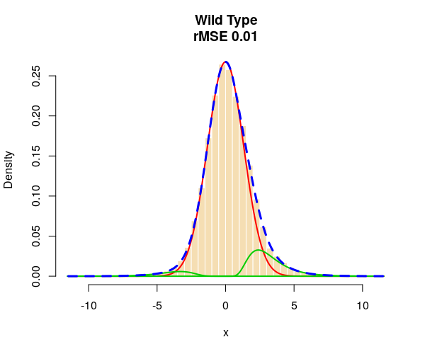

The function **shortSummary** produces the following output:

```
No. nodes = 3,454
Max no. edges = 5,963,331
No. edges detected = 80,332
p1 = 0.0942
p2 = 0.0185
Est. FDR <= 0.00997
```

Note that the estimated FDR is calculated based on the fitted L2N model. The default FDR threshold used by the edgefinder function is 0.01, and in this case, the empirical FDR is very close to the level set by the user. If the empirical FDR is too high, you may increase **LOvals** from its default value (30). This will result in larger (stricter) thresholds for determining significant correlations, and will decrease the proportion of false discoveries. The FDR threshold (the **BHthr** parameter) should be set according to the number of edges. In this example, the algorithm finds 80,332 edges, and an FDR of 0.01 means that at most 800 of the detected edges may not be true discoveries. If this number of edges is too large in the sense that it may affect our inference about the network structure, or a subsequent gene enrichment analysis, we could lower the FDR threshold.

The function **graphComponents** finds clusters of genes. To do that, it takes as input an adjacency (0/1) matrix (e.g. WTres$AdjMat in our example.) To find clusters it first calculates a centrality for each node, using the formula (type*CC+1)*deg where deg is the degree of the node, and CC is its clustering coefficient (CC). **type** is set by default to 1. When it is set to 0, the centrality measure is just the degree of the node. Setting type=1 means that we assign a higher value to nodes that not only have many neighbors, but the neighbors are highly interconnected. For example, suppose we have two components with k nodes, one has a star shape, and the other is a complete graph. With type=0 both graphs will get the same value, but with type=1 the complete graph will be picked by the algorithm first. You can also set a minimum centrality value (the parameter **minCtr**) to determine the smallest possible cluster size.

The function returns a data frame with the following information about each node: a label (e.g. gene name), degree, clustering coefficient, centrality measure, cluster number, iscenter (1 for the node was chosen as the cluster’s center, 0 otherwise), the number of edges from the node to nodes in the same cluster the number of edges from the node to nodes NOT in the same cluster, and the standardized Manhattan distance to the central node in the cluster (in terms of the number neighbors they do not have in common.)

```
WTComp <- graphComponents(WTres$AdjMat)
head(WTComp)

  labels degree        cc      ctr clustNo iscenter intEdges extEdges  distCenter
1      1    251 0.5999044 401.5760       1        0      187       64 0.072958888
2      2      0 0.0000000   0.0000       0        0        0        0 0.000000000
3      3    202 0.7217378 347.7910       1        0      164       38 0.072090330
4      4    202 0.5819910 319.5622       4        0       98      104 0.008396063
5      5      0 0.0000000   0.0000       0        0        0        0 0.000000000
6      6      9 0.6944444  15.2500       0        0        0        0 0.000000000
```

The function **summarizeClusters** returns summary statistics about each cluster. It prints the number of nodes, edges, clusters and unclustered nodes to the screen, and returns a matrix with cluster number, number of nodes in the cluster, fivenum summary for the degrees of nodes in the cluster, and fivenum summary for the percentage of edges that are within the cluster.

```
summtab <- summarizeClusters(WTComp)
head(summtab[,1:7])
head(summtab[,c(1:2,8:12)])

Num of nodes: 3454
Num of edges: 80332
Num of clusters: 72
Num of unclustered nodes: 1837

     Cluster Nodes degreeMin degreeQ25 degreeMedian degreeQ75 degreeMax
[1,]       1   374        59     222.0          257     299.0       373
[2,]       2    69        17      96.0          134     164.0       234
[3,]       3    39         2      53.5           74     122.5       209
[4,]       4   107        25     108.0          130     155.5       209
[5,]       5    35        26      58.5           80     109.0       154
[6,]       6    19        17      45.5           80     108.5       133


     Cluster Nodes pctInClstMin pctInClstQ25 pctInClstMedian pctInClstQ75 pctInClstMax
[1,]       1   374   0.52073733   0.78536585       0.8452080    0.9083969    1.0000000
[2,]       2    69   0.07109005   0.23952096       0.3061224    0.4226804    0.8235294
[3,]       3    39   0.03571429   0.09923455       0.1358025    0.2197585    1.0000000
[4,]       4   107   0.18750000   0.44693586       0.5555556    0.6298886    0.8529412
[5,]       5    35   0.10344828   0.21717172       0.2777778    0.3584826    0.7692308
[6,]       6    19   0.06666667   0.10270206       0.1262136    0.1594156    0.4210526
```

It can be seen, for example, the cluster 1 has 374 nodes, and most of them have many neighbors (more than 75% of them have at least 222 edges), and this cluster is very interconnected (at least 75% of the nodes are mostly connected within the cluster with at least 79% of their edges being inside the cluster.

```
plotCluster(WTres$AdjMat,5,WTComp)
plotCluster(WTres$AdjMat,5,WTComp)
```

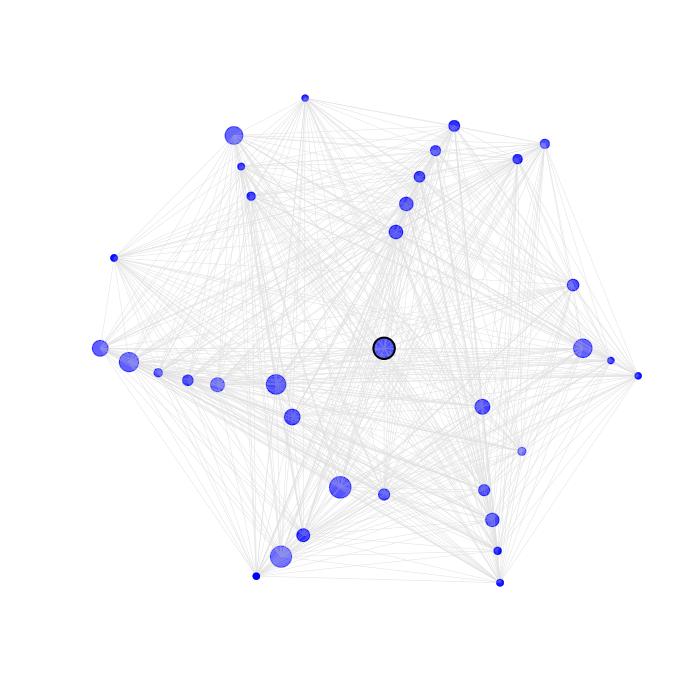

[figure not shown]

Indeed, when we look at the data

```
summtab[9,c(1:2,8:12)]
        Cluster           Nodes    pctInClstMin    pctInClstQ25 pctInClstMedian    pctInClstQ75    pctInClstMax
      9.0000000     108.0000000       0.6857143       0.8768939       0.9301901       0.9657132       1.0000000
```

We see that the cluster contains 108 nodes, and the smallest percentage of within-cluster edges is 68.5%, and for 75% of the nodes, the percentage is greater than 87.6%. This means that cluster 9 is highly inter-connected, and fairly isolated.

We can collapse the network data for more compact visualization by defining a subset in which clusters are represented by their central nodes. The function **collapsedGraph** returns an adjacency matrix which contains all the unclustered nodes, and the centers of the clusters. The elements in the matrix contain the total number of edges in the original graph. That is, the total count of edges between clusters i and j is stored in the matrix, rather than just 0/1. To convert it to a 0/1 adjacency matrix we can use the following:

```
Adj1 <- collapsedGraph(WTres$AdjMat, WTComp) > 0
```

We can use the **igraph** package to visualize the collapsed network. For example, the following code will produce a network graph containing all the clusters and unclustered nodes which have at least one neighbor.

```
library("igraph")
inc <- which(Matrix::rowSums(Adj1) > 0)
plot(graph.adjacency(Adj1[inc,inc], mode="undirected"),
     vertex.label.cex=0.7, vertex.size=0.1, edge.color='lightgreen',asp=1)
```

If we want to show only the relationships between clusters, we use the following:

```
library("igraph")
inc <- which(substr(rownames(Adj1),1,3) == "CLS")
plot(graph.adjacency(Adj1[inc,inc], mode="undirected"),vertex.label.cex=0.7,
vertex.size=0.1,edge.color='lightgreen', asp=1)
```

This gives the following graph, where it can be seen that cluster 9 is connected to clusters 8, 19, 20, 33, and 35.

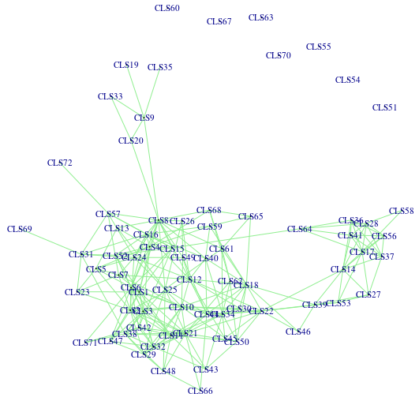

If we want to create a subset of the original data by taking a representative from each clusters, we can do the following

```
WTclustered <- WT[union(which(WTComp$iscenter == 1), which(WTComp$clustNo == 0)),]
dim(WTclustered)
[1] 1909   15
```

*Other visualizations:*

The **plotDegCC** function can be used to plot the degree of nodes versus the degree times the clustering coefficient of nodes. We can also highlight specific groups. For example, in the following code we highlight cluster 1, which as we’ve seen before, is a large (374 genes) and highly connected 75% of the nodes have at least 222 neighbors, and most of the connections are within the cluster (75% of the nodes have at least 78.5% of their neighbors within the cluster.)

```
plotDegCC(WTres,WTComp,highlightNodes = which(WTComp$clustNo==1))
```

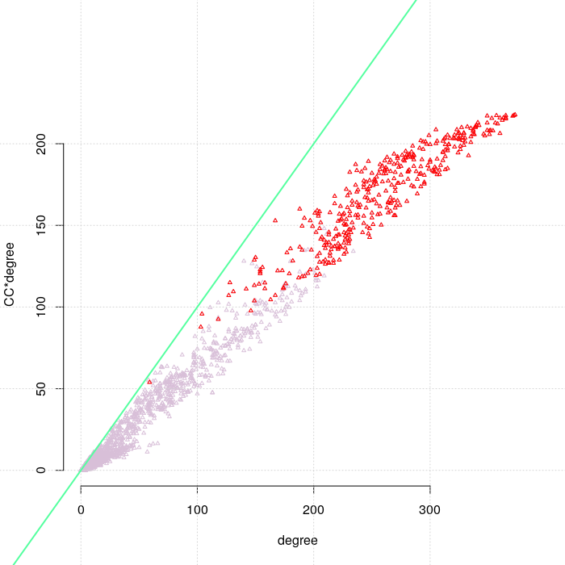

```
plotBitmapCC(WTres$AdjMat, WTComp, orderByCluster=TRUE, showMinDegree = 30)
```

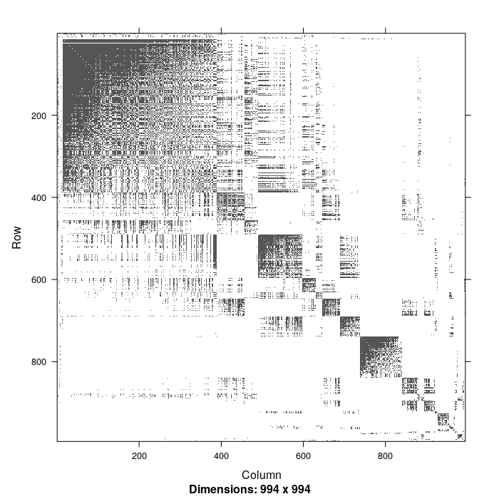

We repeat the same process with the duplication group. DUP is a matrix with 3454 rows (genes) and 12 columns (samples). We only show the collapsed cluster plot, and observe that unlike the WT group, the network in the DUP group consists of two “super-clusters”.

```
data("DUP")
DUPres <- edgefinder(DUP, ttl = "Duplication")
DUPComp <- graphComponents(DUPres$AdjMat)
Adj2 <- collapsedGraph(DUPres$AdjMat, DUPComp) > 0
inc <- which(substr(rownames(Adj2),1,3) == "CLS")
plot(graph.adjacency(Adj2[inc,inc], mode="undirected"),vertex.label.cex=0.7,
vertex.size=0.1,edge.color='lightgreen', asp=1)
```

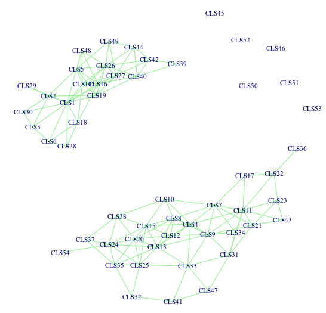

# Simulated data

The following examples shows a simulated dataset with a hub structure, consisting of 1000 nodes and 50 hubs. The bitmap plot shows the network that was created by edgefinder.

```
library("huge")
library("MASS")
N=200; D=1000
set.seed(23197)
L = huge.generator(n = N, d = D, graph = "hub", g=50,  v = 0.3, u = 0.1)
x = mvrnorm(N, rep(0, D), L$sigma)
```

Data generated like this is provided with the package in a dataset called SIM. We perform similar analysis and display the bitmap plot, which shows that edgefinder finds the actual network structure overall, with almost no false discoveries. We also display the network of cluster 1, which shows that the cluster is how we expected it to be, with one central node with high degree (the hub gene), with interconnected neighbors each having a smaller degree than the hub gene. From the dark shade of blue for each node, we can infer that the nodes are connected within the cluster but almost no edges to other clusters or nodes. The smallest percentage of edges within cluster 1 is 66.7%, and at least 75% of the nodes are connected only to nodes within the same cluster.

```
data(SIM)
Sres <- edgefinder(SIM, ttl = "Simulation", BHthr=0.05)
plotBitmapCC(Sres$AdjMat,orderByCluster=FALSE)
SIMComp <- graphComponents(Sres$AdjMat)
plotCluster(Sres$AdjMat,1,SIMComp)
sumtab <- summarizeClusters(SIMComp)
sumtab[1,c(1:2,8:12)]

Cluster Nodes   pctInClstMin  pctInClstQ25 pctInClstMedian   pctInClstQ75  pctInClstMax
      1    20      0.6666667     1.0000000       1.0000000      1.0000000     1.0000000
```

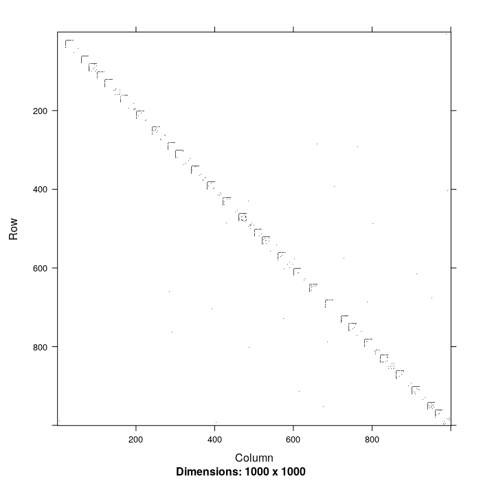

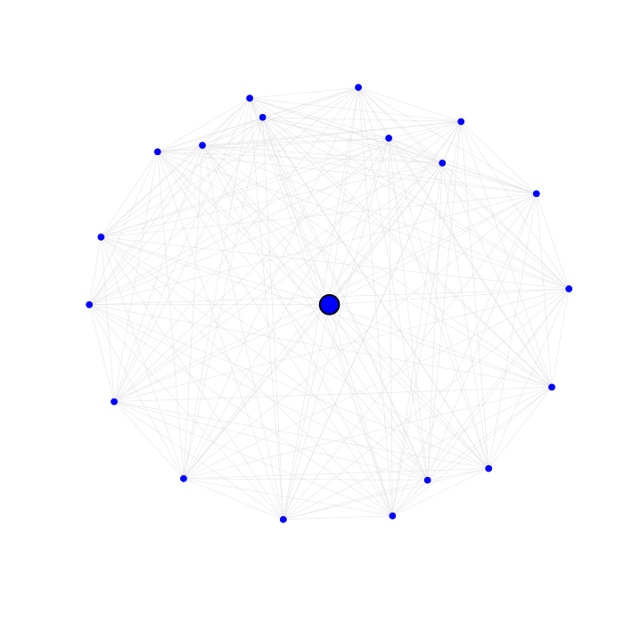